# HATCHER_Skills_Test_3

2025-04-20

## 1. Load and clean FacultySalaries_1995.csv file and Re-create the given graph:

First we need to clean the data by taking the three columns AvgFullProfSalary, AvgAssocProfSalary, AvgAssistProfSalary and assigning their names to Rank and values to Salary (make the data set longer).

```r
faculty_long <- fac_dat %>%
  pivot_longer(
    cols = c(AvgFullProfSalary, AvgAssocProfSalary, AvgAssistProfSalary),
    names_to = "Rank",
    values_to = "Salary") %>%
  mutate(Rank = case_when(
    Rank == "AvgFullProfSalary" ~ "Full",
    Rank == "AvgAssocProfSalary" ~ "Assoc",
    Rank == "AvgAssistProfSalary" ~ "Assist",
    TRUE ~ Rank))
```

The variables rank, tier, and state need to be converted into factors for plotting.

```r
faculty_long$Rank <- as.factor(faculty_long$Rank)
faculty_long$Tier <- as.factor(faculty_long$Tier)
faculty_long$State <- as.factor(faculty_long$State)
```

Now we create a boxplot faceted by tier with the x-axis as rank, y-axis as salary, and fill as rank.

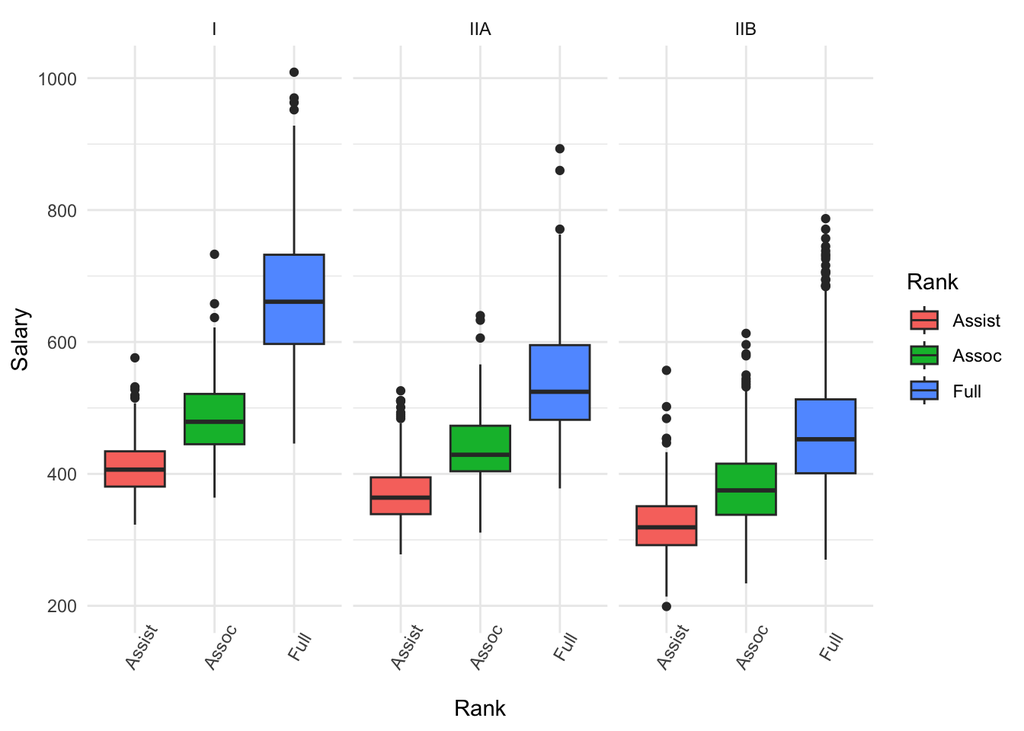

```r
faculty_long_plot <- filter(faculty_long, Tier != "VIIB")

ggplot(faculty_long_plot, aes(x = Rank, y = Salary, fill = Rank)) +
  geom_boxplot() +
  facet_wrap(~ Tier) +
  labs(y = "Salary", x = "Rank") +
  theme_minimal() +
  theme(axis.text.x = element_text(angle = 60))
```

## 2. Build an ANOVA model and display the summary output.

The model tests the influence of state, tier, and rank on salary but does not include any interactions between the predictors.

```r
anova_mod <- aov(data = faculty_long, Salary ~ State + Tier + Rank)

summary(anova_mod)
```

```
##               Df   Sum Sq Mean Sq F value Pr(>F)
## State         51  5682396  111420   30.66 <2e-16 ***
## Tier           2  7072361 3536180  972.96 <2e-16 ***
## Rank           2 16529771 8264885 2274.04 <2e-16 ***
## Residuals   3299 11990072    3634
## ---
## Signif. codes:  0 '***' 0.001 '**' 0.01 '*' 0.05 '.' 0.1 ' ' 1
## 128 observations deleted due to missingness
```

Based on the ANOVA model above, we can conclude that all three variables (State, Tier, and Rank) have effects on faculty salaries that are statistically significant (the chance that these differences occurred due to chance is incredibly unlikely).

Since Rank has the highest sum of squares and the highest F-value, we can conclude that Rank is the most important variable in explaining salary.

Although all three variables are significant, which state a professor works in matters the least compared to their rank or university tier.

## 3. Load and look at “Juniper_Oils.csv” data and then tidy it.

We first need to load in the data set Juniper_Oils.csv and take a look at the structure.

```r
juniper_dat <- read.csv("Juniper_Oils.csv")

str(juniper_dat)
```

```
## 'data.frame':    34 obs. of  41 variables:
##  $ SampleID              : chr  "LOG-16S-SL12" "LOG-16S-SL11" "LOG-16S-CC5" "LOG-16S-SL9" ...
##  $ Project               : chr  "JuniperLogs" "JuniperLogs" "JuniperLogs" "JuniperLogs" ...
##  $ Amplicon              : chr  "16S" "16S" "16S" "16S" ...
##  $ Tree_Species          : chr  "Juniperus osteosperma" "Juniperus osteosperma" "Juniperus osteosperma" "Juniperus osteosperma" ...
##  $ BurnYear              : int  2018 2017 2016 2014 2013 2012 2011 2009 2008 2007 ...
##  $ Latitude              : num  41.6 40.9 37.6 39.9 41.5 ...
##  $ Longitude             : num  -114 -113 -113 -113 -114 ...
##  $ Field_Office          : chr  "Salt_Lake_3" "Salt_Lake_2" "Cedar_City" "Salt_Lake_4" ...
##  $ BLM_Fire_Name         : chr  "Ridge" "Knob" "Hicks Creek" "Lion Peak" ...
##  $ Tracking_Number       : chr  "#5276 (2018)" "#5275 (2017)" "#5274 (2016)" "#5273 (2014)" ...
##  $ alpha.pinene          : num  0.6 1.4 0.2 0.3 0.1 0 0.1 0.2 0.1 0.1 ...
##  $ para.cymene           : num  0.4 0.3 1.1 0.1 0.1 0.1 0.5 0.6 0.2 0.3 ...
##  $ alpha.terpineol       : num  2.3 0.5 0.8 0.7 0.2 0.1 2.8 1.1 0.1 0.3 ...
##  $ cedr.9.ene            : num  0.2 1 1.1 0.7 1 0.3 0.4 0.5 0.9 0.8 ...
```

[output cut: 27 more lines]

Now we need to make a vector of the chemical compound names and then tidy up the chemical data while keeping the rest.

```r
chemicals <- c("alpha.pinene","para.cymene","alpha.terpineol","cedr.9.ene",
               "alpha.cedrene","beta.cedrene","cis.thujopsene","alpha.himachalene",
               "beta.chamigrene","cuparene","compound.1","alpha.chamigrene",
               "widdrol","cedrol","beta.acorenol","alpha.acorenol","gamma.eudesmol",
               "beta.eudesmol","alpha.eudesmol","cedr.8.en.13.ol","cedr.8.en.15.ol",
               "compound.2","thujopsenal")


juniper_tidy <- juniper_dat %>%
  pivot_longer(cols = all_of(chemicals),
               names_to = "ChemicalID",
               values_to = "Concentration")
```

The structure of the newly created data set is now longer and much more tidy.

```r
str(juniper_tidy)
```

```
## tibble [782 × 20] (S3: tbl_df/tbl/data.frame)
##  $ SampleID              : chr [1:782] "LOG-16S-SL12" "LOG-16S-SL12" "LOG-16S-SL12" "LOG-16S-SL12" ...
##  $ Project               : chr [1:782] "JuniperLogs" "JuniperLogs" "JuniperLogs" "JuniperLogs" ...
##  $ Amplicon              : chr [1:782] "16S" "16S" "16S" "16S" ...
##  $ Tree_Species          : chr [1:782] "Juniperus osteosperma" "Juniperus osteosperma" "Juniperus osteosperma" "Juniperus osteosperma" ...
##  $ BurnYear              : int [1:782] 2018 2018 2018 2018 2018 2018 2018 2018 2018 2018 ...
##  $ Latitude              : num [1:782] 41.6 41.6 41.6 41.6 41.6 ...
##  $ Longitude             : num [1:782] -114 -114 -114 -114 -114 ...
##  $ Field_Office          : chr [1:782] "Salt_Lake_3" "Salt_Lake_3" "Salt_Lake_3" "Salt_Lake_3" ...
##  $ BLM_Fire_Name         : chr [1:782] "Ridge" "Ridge" "Ridge" "Ridge" ...
##  $ Tracking_Number       : chr [1:782] "#5276 (2018)" "#5276 (2018)" "#5276 (2018)" "#5276 (2018)" ...
##  $ Yield_percent         : num [1:782] 0.18 0.18 0.18 0.18 0.18 0.18 0.18 0.18 0.18 0.18 ...
##  $ Bolt_Surface_Area_cm2 : int [1:782] 1687 1687 1687 1687 1687 1687 1687 1687 1687 1687 ...
##  $ Raw_Exit_Holes_per_cm2: num [1:782] 0 0 0 0 0 0 0 0 0 0 ...
##  $ Raw_Exit_Holes        : int [1:782] 0 0 0 0 0 0 0 0 0 0 ...
##  $ Living_Larvae         : int [1:782] 0 0 0 0 0 0 0 0 0 0 ...
##  $ ChemTotal             : num [1:782] 87.7 87.7 87.7 87.7 87.7 87.7 87.7 87.7 87.7 87.7 ...
##  $ ChemMean              : num [1:782] 3.81 3.81 3.81 3.81 3.81 ...
##  $ YearsSinceBurn        : int [1:782] 2 2 2 2 2 2 2 2 2 2 ...
##  $ ChemicalID            : chr [1:782] "alpha.pinene" "para.cymene" "alpha.terpineol" "cedr.9.ene" ...
##  $ Concentration         : num [1:782] 0.6 0.4 2.3 0.2 1.9 1.2 25.9 0.2 0.4 1.8 ...
```

## 4. Make the given graph.

Now we make a plot faceted by ChemicalID that shows the Concentration of each chemical over time (YearsSinceBurn).

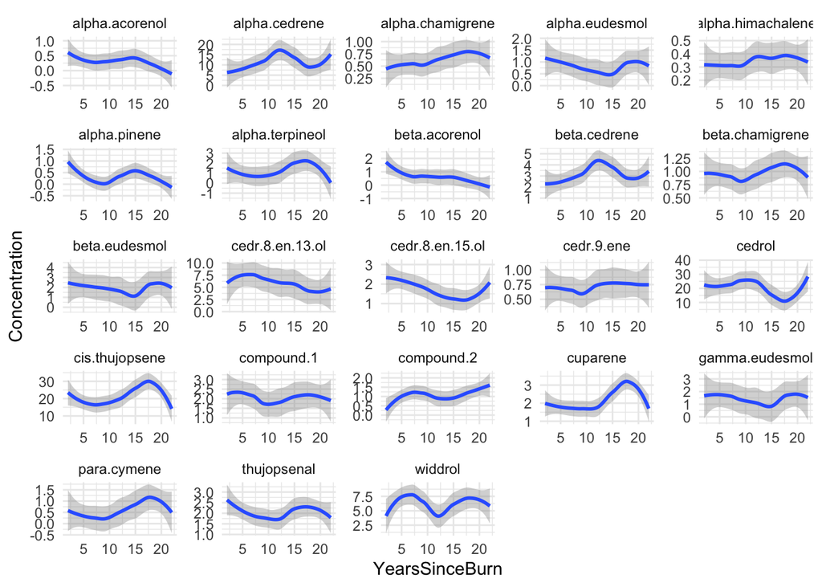

```r
ggplot(data = juniper_tidy, aes(x = YearsSinceBurn, y = Concentration)) +
  geom_smooth() +
  facet_wrap(~ ChemicalID, scales = "free") +
  theme_minimal() +
  labs(x = "YearsSinceBurn", y = "Concentration")
```

## 5. Use a generalized linear model to find which chemicals show concentrations that are significantly (significant, as in P < 0.05) affected by “Years Since Burn”.

```r
glm_signif_results <- juniper_tidy %>%
  group_by(ChemicalID) %>%
  nest() %>%
  mutate(model = map(data, function(new_df) glm(Concentration ~ YearsSinceBurn, data = new_df))) %>%
  mutate(tidy_model = map(model, tidy)) %>%
  unnest(tidy_model) %>%
  filter(p.value < 0.05) %>%
  select(ChemicalID, term, estimate, std.error, statistic, p.value)

print(glm_signif_results, n = Inf)
```

```
## # A tibble: 24 × 6
## # Groups:   ChemicalID [21]
##    ChemicalID        term           estimate std.error statistic       p.value
##    <chr>             <chr>             <dbl>     <dbl>     <dbl>         <dbl>
##  1 alpha.pinene      (Intercept)      0.596     0.189       3.15 0.00354
##  2 cedr.9.ene        (Intercept)      0.672     0.132       5.11 0.0000144
##  3 alpha.cedrene     (Intercept)      8.43      2.90        2.90 0.00663
##  4 beta.cedrene      (Intercept)      2.67      0.545       4.89 0.0000276
##  5 cis.thujopsene    (Intercept)     17.8       3.28        5.43 0.00000571
##  6 alpha.himachalene (Intercept)      0.306     0.0580      5.29 0.00000860
##  7 beta.chamigrene   (Intercept)      0.913     0.141       6.47 0.000000283
##  8 cuparene          (Intercept)      1.53      0.333       4.60 0.0000631
##  9 cuparene          YearsSinceBurn   0.0550    0.0244      2.26 0.0310
## 10 compound.1        (Intercept)      2.27      0.386       5.90 0.00000147
## 11 alpha.chamigrene  (Intercept)      0.450     0.130       3.45 0.00160
## 12 widdrol           (Intercept)      6.36      1.23        5.19 0.0000116
## 13 cedrol            (Intercept)     23.1       4.17        5.54 0.00000414
## 14 beta.acorenol     (Intercept)      1.38      0.309       4.46 0.0000959
## 15 beta.acorenol     YearsSinceBurn  -0.0655    0.0226     -2.90 0.00664
## 16 alpha.acorenol    (Intercept)      0.547     0.157       3.48 0.00148
## 17 gamma.eudesmol    (Intercept)      1.53      0.623       2.46 0.0196
## 18 beta.eudesmol     (Intercept)      1.98      0.749       2.64 0.0127
## 19 alpha.eudesmol    (Intercept)      0.908     0.292       3.12 0.00386
## 20 cedr.8.en.13.ol   (Intercept)      8.17      1.52        5.36 0.00000705
## 21 cedr.8.en.15.ol   (Intercept)      2.26      0.299       7.56 0.0000000130
## 22 compound.2        (Intercept)      0.662     0.236       2.80 0.00851
## 23 compound.2        YearsSinceBurn   0.0356    0.0173      2.06 0.0471
## 24 thujopsenal       (Intercept)      2.16      0.261       8.29 0.00000000182
```